# Frequency of Bicycle Station usage in Oslo

G. Jan

19 August 2018

# Intro

In recent years bicycle sharing has become more and more present in Oslo. It provides an alternative to other modes of transport as well as filling the gaps left by public transports. They are many benefits provided by bicycle sharing: times of commuting trips can be potentially reduced, no bicycle theft, health improvement…

The main objective of this paper is to brush some initial ideas on which factors influence the frequency usage of the bicycle stations and to quantify them. Those factors will be used in order to predict wether a bicycle station has a low or high frequency usage. You can find all the R code used for this work [here](https://github.com/GregoireJan/OsloBysykkel).

The rest of the paper is organized as follows:

1. Data handling
   - Importing & Cleaning Data
   - Exploring Data through Visualizations
2. Data analysis
   - Data splitting
   - Logit regression
   - Naive Bayes
   - Decision Tree
   - SVM
3. Conclusion

# Data Handling

## Importing & Cleaning Data

This section shows the importing and cleaning data process in order to get it ready for data exploration. The final data frame includes the following variables for each bicycle station: ID, Title, Subtitle, Neighborhood, Longitude, Latitude, Elevation, FrequencyStart, FrequencyEnd, FrequencyTotal, FrequencyFactor, TotalPopulation, RatioYoungPopulation, Transport, DistanceSentrum, NumberLocks.

Those variables were chosen according to the available open-source data at my disposition as well as time constrain.

The following R libraries are used for all the subsequent coding.

```r
# Libraries
library(jsonlite)
library(rgbif)
library(ggmap)
library(dplyr)
library(stringr)
library(leaflet)
library(XML)
library(NISTunits)
library(caret)
library(mltools)
library(e1071)
library(rpart)
library(kernlab)
```

The first step is to import the data from the Oslo Bysykkel API (https://developer.oslobysykkel.no/api). The json file is downloaded using the following curl command.

```
curl -H "Client-Identifier: b57bc989e4b96f1040aa1752e98780c9" https://oslobysykkel.no/api/v1/stations
```

From the JSON file we can get the address of each station from the latitude and longitude coordinates using the google API. From the address we only keep the postcode and the following variables: id, title, subtitle, number_of_locks, longitude and latitude.

```r
# Read oslo bysykkel station JSON file

#  Mined from https://developer.oslobysykkel.no/api
st <- fromJSON("/home/greg/Documents/Candidature/Bysykkel/oslobysykkel_station.json")
station <- st$stations

station$longitude <- station$center$longitude
station$latitude <- station$center$latitude

station$address <- NA

# Get address from latitude and longitude using google API
while( anyNA(station$address) ) {
  for( i in 1:nrow(station) ) {
    if( is.na(station[i,"address"]) ) {
      station$address[i] <- revgeocode( as.numeric(station[i, c("longitude","latitude")]), output = "address" )
    }
  }
}

# Create postcode variable from address
station$postcode <- str_extract(station$address, "[0-9]{4}")
# Keep the following variables: id. title, subtitle, number_of_locks, longitude,latitude,postcode
station2 <- station[,c(1,3,4,5,8,9,11)]
```

The next step is to extract the neighborhood name from each stations postcode. This will be done using a csv table from https://www.erikbolstad.no/postnummer-koordinatar/txt/postnummer.csv.

```r
# Read post number to get neighborhood name using https://www.erikbolstad.no/postnummer-koordinatar/txt/postnummer.csv

postnum <- read.csv("/home/greg/Documents/Candidature/Bysykkel/postnummer.csv",sep="\t")
postoslo <- postnum[postnum$POSTSTAD=="Oslo",c(3,6)]
postoslo$POSTNR..OG.STAD <- gsub("OSLO","",postoslo$POSTNR..OG.STAD)
names(postoslo) <- c("postcode","Bydel")

# Prepare variable for merging to get neighborhood for each bicycle station
postoslo$Bydel <- as.character(postoslo$Bydel)
station2$postcoden <- as.numeric(station$postcode)
postoslo$postcoden <- as.numeric(postoslo$postcode)
# Left outer join
merge <- merge(station2,postoslo,by="postcoden",all.x=TRUE,sort=FALSE)
merge <- merge[,c(2:7,10)]
merge$Bydel <- as.character(merge$Bydel)
```

Since the neighborhood name is now known for each station we can get the following variables: Total Population and the ratio young over old people in the neighborhoods. We will consider that the young people ranges from 16 to 39 years old and the old people ranges from 40 to 79 years old. The ratio will give us an indication on how young is the population in the given neighborhood.

```r
# Import data for each neighborhood

# Data from https://www.ssb.no/a/kortnavn/folkemengde/tab-2012-03-14-22.html
folk <- read.table("/home/greg/Documents/Candidature/Bysykkel/bydelfolk.csv",sep = ",")
names(folk) <- c("Bydel","TotalPop","0","1-4","5","6-12","13-15","16-19","20-39","40-54","55-66","67-79","80-89","90-")
folk$Bydel<- gsub("[0-9]","",folk$Bydel)
folk$Bydel<- gsub("^ ","",folk$Bydel)
folk$Bydel<- gsub("St. Hanshaugen","St.Hanshaugen",folk$Bydel)
folk <- folk[2:19,]
folk[,2:14] <- as.data.frame(lapply(folk[,2:14], function(x) as.numeric(as.character(gsub(" ","",x)))))
folk$Young <- folk$`20-39`+ folk$`16-19`
folk$Old <- folk$`40-54`+folk$`55-66`+folk$`67-79`
folk$RatioYoungPop <- folk$Young/(folk$Young+folk$Old)

# Get population and age ratio for each neighborhood into main data.frame
merge <- merge(merge,folk[,c("Bydel","TotalPop","RatioYoungPop")],by="Bydel",all.x=TRUE,sort = FALSE)
```

The following step computes the elevations for each station using the Google API.

```r
# Get elevation for bicycle stations

merge$elev <- NA

# Use google api to get elevation of each bicycle station
while( anyNA(merge$elev) ) {
  for( i in 1:nrow(merge) ) {
    if( is.na(merge[i,"elev"]) ) {
      merge$elev[i] <- elevation(latitude = merge$latitude[i],longitude = merge$longitude[i],key=gapi)[[3]]
    }
  }
}
```

This step is designed to extract the frequency of each station from April to December 2017 (1 year bicycle sharing activity in Oslo). The data is imported from https://developer.oslobysykkel.no/data. In addition to the total frequency we compute frequencies of both the starting and ending trip.

```r
# Get all trafic for each station from april to december 2017

url <- NA
dest <- NA
for (i in 18:26) {
  url[i-17] <- paste("https://developer.oslobysykkel.no/data/",i,sep="")
  dest[i-17] <- paste("/home/greg/Documents/Candidature/Bysykkel/",paste(i,"_2017.csv",sep=""),sep = "")}
url <- paste(url,".csv",sep = "")
for (i in 1:9) {
download.file(url[i],dest[i],mode = "wb")}

# Merge all csv files together
setwd("/home/greg/Documents/Candidature/Bysykkel/")
lapply(list.files(pattern="*_2017.zip"),unzip)
```

```
## [[1]]
## [1] "./trips-2017.4.1-2017.4.30.csv"
##
## [[2]]
## [1] "./trips-2017.5.1-2017.5.31.csv"
##
## [[3]]
## [1] "./trips-2017.6.1-2017.6.30.csv"
##
## [[4]]
## [1] "./trips-2017.7.1-2017.7.31.csv"
##
## [[5]]
## [1] "./trips-2017.8.1-2017.8.31.csv"
##
## [[6]]
## [1] "./trips-2017.9.1-2017.9.30.csv"
##
## [[7]]
## [1] "./trips-2017.10.1-2017.10.31.csv"
##
## [[8]]
## [1] "./trips-2017.11.1-2017.11.30.csv"
##
## [[9]]
## [1] "./trips-2017.12.1-2017.12.31.csv"
```

```r
trips <- do.call(rbind,lapply(list.files(pattern="trips-2017*"),read.csv))
# Get frequency for starting and ending trips
tripstart <- as.data.frame(table(trips$Start.station),col.names=c("Start.station","Freq"))
names(tripstart) <- c("Start.station","FreqStart")
tripend <- as.data.frame(table(trips$End.station),col.names=c("End.station","Freq"))
names(tripend) <- c("End.station","FreqEnd")

# Merge starting and ending trips with main data frame
merge2 <- merge(merge,tripstart,by.x="id",by.y="Start.station",all.x=TRUE,sort=FALSE)
merge2 <- merge(merge2,tripend,by.x="id",by.y="End.station",all.x=TRUE,sort=FALSE)

# Compute total frequency for each station
merge2$FreqTotal <- merge2$FreqStart + merge2$FreqEnd
# Compute difference between starting and ending for each station
merge2$FreqDiff <- merge2$FreqStart - merge2$FreqEnd
```

The last step on this section is using XML data sets of all the transport stations in Oslo from the Statistik Sentralbyrå (https://storage.googleapis.com/marduk-production/tiamat/Oslo_og_Akershus_latest.zip). For each bicycle station we compute the number of public transport stations within 300 meter, a walk-able distance. In addition the distance from each bicycle station to the center (Oslo Domkirke) is also computed.

```r
# Import transport stops info for Oslo
# https://storage.googleapis.com/marduk-production/tiamat/Oslo_og_Akershus_latest.zip

xmlfile <- xmlTreeParse("/home/greg/Documents/Candidature/Bysykkel/Oslo_og_Akershus-export-20180802-013420-13604389.xml",useInternalNodes=TRUE)
xmllist <- xmlToList(xmlfile)
xmlstop <- xmllist$dataObjects$SiteFrame$stopPlaces

name <- NA
longitude <- NA
latitude <- NA
TransportMode <- NA

# Extract name, latitude, longitude for each transport station
for (i in seq(length(xmlstop))) {
  name[i] <- xmlstop[i][["StopPlace"]][["Name"]][["text"]]
  longitude[i] <- xmlstop[i][["StopPlace"]][["Centroid"]][["Location"]][["Longitude"]]
  latitude[i] <- xmlstop[i][["StopPlace"]][["Centroid"]][["Location"]][["Latitude"]]
  ifelse(is.null(xmlstop[[i]]$TransportMode),TransportMode[i]<-NA,TransportMode[i] <-xmlstop[[i]]$TransportMode)
}
stop <- as.data.frame(cbind(name,longitude,latitude,TransportMode),stringsAsFactors = FALSE)
stop2 <- na.omit(stop)

# Compute the number of transport station less than than 300m next to each bicycle stations
merge2$transport <- 0
for (i in seq(nrow(merge2))) {
    lat <- merge2[i,"latitude"]
    lon <- merge2[i,"longitude"]
    n <- 0
    for (j in seq(nrow(stop2))) {
      R <-  6371e3
      t1 <- NISTdegTOradian(lat)
      t2 <- NISTdegTOradian(as.numeric(stop2[j,"latitude"]))
      dt <- NISTdegTOradian(as.numeric(stop2[j,"latitude"])-lat)
      da <- NISTdegTOradian(as.numeric(stop2[j,"longitude"])-lon)

      a = sin(dt/2) * sin(dt/2) + cos(t1) * cos(t2) *  sin(da/2) * sin(da/2)
      c = 2 * atan2(sqrt(a), sqrt(1-a))
      d = R * c
      if (d < 300) {n <- n + 1}
    }
    merge2[i,"transport"] <- n
}
# Compute the distance to the sentrum  (Oslo domkirke) for each bicycle stations
for (i in seq(nrow(merge2))) {
  lat <- merge2[i,"latitude"]
  lon <- merge2[i,"longitude"]
  R <-  6371e3
  t1 <- NISTdegTOradian(lat)
  t2 <- NISTdegTOradian(59.912592)
  dt <- NISTdegTOradian(59.912592-lat)
  da <- NISTdegTOradian(10.746755-lon)

  a = sin(dt/2) * sin(dt/2) + cos(t1) * cos(t2) *  sin(da/2) * sin(da/2)
  c = 2 * atan2(sqrt(a), sqrt(1-a))
  merge2[i,"DistSentrum"] <- R * c
}

merge.final<- na.omit(merge2)
```

## Exploring Data through Visualizations

Let us have a look first at the Total Frequency variable.

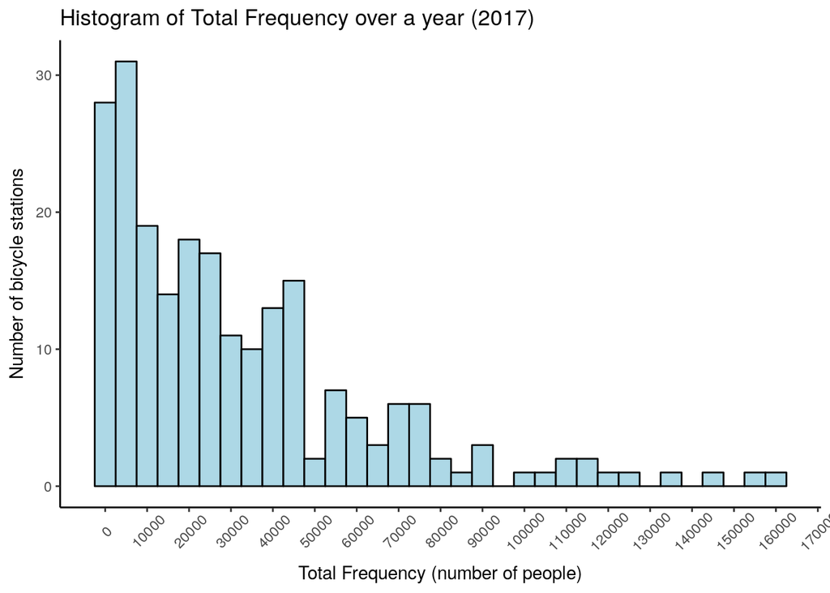

```r
library(ggplot2)

ggplot(merge.final, aes(x=FreqTotal)) + geom_histogram(binwidth = 5000,fill="lightblue",color="black") + scale_x_continuous(breaks = seq(0,200000,by=10000)) + theme_classic() + theme(axis.text.x = element_text(angle=45,vjust = 0.65)) + xlab("Total Frequency (number of people)") + ylab("Number of bicycle stations") + ggtitle("Histogram of Total Frequency over a year (2017)")
```

The histogram shows that the number of bicycle stations is clearly exponentially decreasing with Total Frequency. We can see that the highest ranges are 0-2500 and 2500-7500 people which are the 2 first ranges. From this observation we derive a binary Total Frequency Factor whose values 0 and 1 are respectively defining Low and High Total Frequency with a threshold at 7500 people. This variable will be the outcome of our prediction. The reasons behind this choice is that predicting a binary outcome is simpler and is an acceptable first step in this work at the current stage.

The following box plot show each variable which will be used in the prediction versus the Frequency Factor.

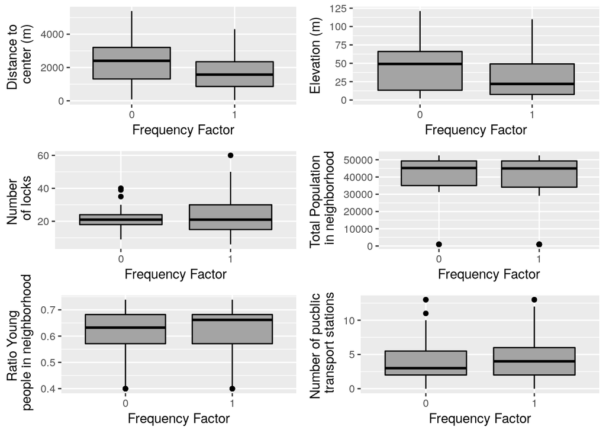

```r
# Compute simple binary variable for low vs high frequency station: threshold at 7500ppl
merge.final$FreqTotF <- cut(merge.final$FreqTotal,breaks = c(0,7500,Inf),labels = c(0,1))


library(gridExtra)
p1 <- ggplot(merge.final, aes(x=FreqTotF,y=DistSentrum,group=FreqTotF)) + geom_boxplot(fill='#A4A4A4', color="black") + labs(y="Distance to \n center (m)",x="Frequency Factor")
p2 <- ggplot(merge.final, aes(x=FreqTotF,y=elev,group=FreqTotF)) + geom_boxplot(fill='#A4A4A4', color="black") + labs(y="Elevation (m)",x="Frequency Factor")
p3 <- ggplot(merge.final, aes(x=FreqTotF,y=number_of_locks,group=FreqTotF)) + geom_boxplot(fill='#A4A4A4', color="black") + labs(y="Number \n of locks",x="Frequency Factor")
p4 <- ggplot(merge.final, aes(x=FreqTotF,y=TotalPop,group=FreqTotF)) + geom_boxplot(fill='#A4A4A4', color="black") + labs(y="Total Population \n in neighborhood",x="Frequency Factor")
p5 <- ggplot(merge.final, aes(x=FreqTotF,y=RatioYoungPop,group=FreqTotF)) + geom_boxplot(fill='#A4A4A4', color="black") + labs(y="Ratio Young \n people in neighborhood",x="Frequency Factor")
p6 <- ggplot(merge.final, aes(x=FreqTotF,y=transport,group=FreqTotF)) + geom_boxplot(fill='#A4A4A4', color="black") + labs(y="Number of pucblic \n transport stations",x="Frequency Factor")
grid.arrange(p1, p2,p3,p4,p5,p6, nrow = 3,ncol = 2)
```

```r
box <- as.list("Outliers")
box$"Distance to center" <- boxplot.stats(merge.final$DistSentrum)$out
box$"Elevation" <- boxplot.stats(merge.final$elev)$out
box$"Number of locks" <- boxplot.stats(merge.final$number_of_locks)$out
box$"Total Population in neighborhood" <- boxplot.stats(merge.final$TotalPop)$out
box$"Ratio Young  people in neighborhood" <- boxplot.stats(merge.final$RatioYoungPop)$out
box$"Number of public transport stations" <- boxplot.stats(merge.final$transport)$out
print(box)
```

```
## [[1]]
## [1] "Outliers"
##
## $`Distance to center`
## [1] 5392.535
##
## $Elevation
## numeric(0)
##
## $`Number of locks`
## [1] 50 48 48 60
##
## $`Total Population in neighborhood`
##  [1] 963 963 963 963 963 963 963 963 963 963 963 963 963 963 963 963 963
## [18] 963 963 963 963 963 963 963 963 963 963 963 963 963 963 963 963
##
## $`Ratio Young  people in neighborhood`
## [1] 0.3997634 0.3997634 0.3997634 0.3997634 0.3997634 0.3997634 0.3997634
## [8] 0.3997634 0.3997634
##
## $`Number of public transport stations`
## [1] 13 13 13 13
```

Looking at the values seen as outliers I am confident that those values should remain in the data. None of them looks inapropriate.

The next 2 plots are maps of Oslo with all the Bysykkel stations respectively showing the Total Frequency and the Frequency Factor. By clicking on the dots one can see the name and the frequency of the selected station.

```r
library(leaflet)
 pal <- colorNumeric(
   palette = 'Reds',
   domain = merge.final$FreqTotal)

leaflet() %>% addTiles() %>% addCircleMarkers(data = merge.final ,lat = ~latitude, lng = ~longitude,stroke=FALSE,fillColor=~pal(FreqTotal),fillOpacity = 0.75,popup = ~paste(sep = "<br/>",title,as.character(FreqTotal))) %>% addLegend(pal = pal,values=  merge.final$FreqTotal,title="Total Frequency (2017)")
```

[interactive chart not shown]

```r
library(leaflet)
 pal <- colorFactor(
   palette = 'Blues',
   domain = as.factor(merge.final$FreqTotF))

leaflet() %>% addTiles() %>% addCircleMarkers(data = merge.final ,lat = ~latitude, lng = ~longitude,stroke=FALSE,fillColor=~pal(as.factor(FreqTotF)),fillOpacity = 0.75,popup = ~paste(sep = "<br/>",title,as.character(FreqTotal))) %>% addLegend(pal = pal,values=  as.factor(merge.final$FreqTotF),title = "Frequency Factor")
```

[interactive chart not shown]

Finally we look at the number of Low and High frequency bicycle stations.

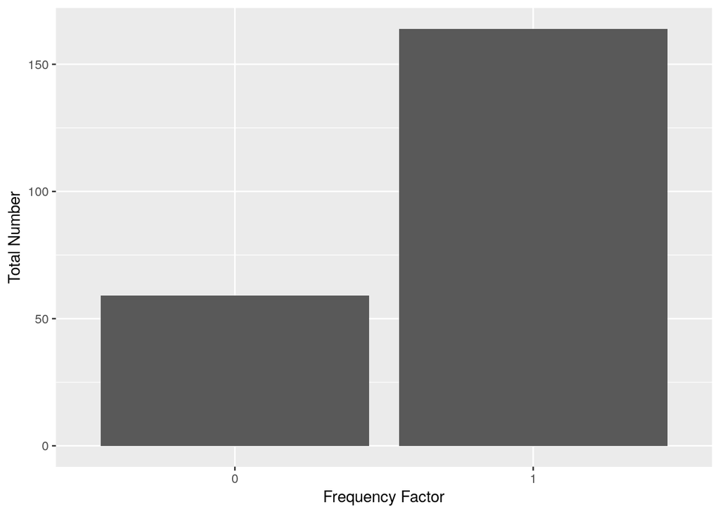

```r
ggplot(as.data.frame(table(merge.final$FreqTotF)), aes(x=Var1,y=Freq)) + geom_bar(stat = "identity") + labs(x="Frequency Factor",y="Total Number")
```

We can clearly see that there are much less Low frequency stations making 26.5% of our data sets.

# Data Analysis

Since we now have a data frame with all our variables we can apply some machine learning algorithms in order to predict the Frequency Factor and assess the accuracy of their outcomes. The Frequency Factor is a simple binary Classifier so I have selected a few of the classifier algorithms.

In order to evaluate each outcomes we will use confusion matrix and Mathews Correlation Coefficients. MCC is a correlation coefficient between target and predictions. It generally varies between -1 and +1. -1 when there is perfect disagreement between actuals and prediction, 1 when there is a perfect agreement between actuals and predictions. 0 when the prediction may as well be random with respect to the actuals.

## Data splitting

```r
# Data slicing : training and validation dataset with 70% threshold
set.seed(333)

trainpart <- createDataPartition(y=merge.final$FreqTotF, p=0.7, list=FALSE)
training <- merge.final[trainpart, ]
testing <- merge.final[-trainpart, ]
```

## Logit Regression Model

Logistic regression is a popular statistical technique to predict binomial outcomes. It generates the coefficients (and its standard errors and significance levels) of a formula to predict a logit transformation of the probability of presence of the characteristic of interest:

$$log(odds)=log(\frac{p}{1-p})=\beta_0 + \beta_1*X_1+\beta_2*X_2+ ... + \beta_i*X_i$$
with $p$ the probability of success, $\beta$ the coefficients and $X$ the input features.

```r
# Logit regression
fitlg<- train(FreqTotF ~ elev + DistSentrum + RatioYoungPop + transport + number_of_locks + TotalPop,data=training,method='glm',family="binomial",trControl = trainControl(method = 'cv', number = 5))

# Summary output with coefficients
summary(fitlg)
```

```
##
## Call:
## NULL
##
## Deviance Residuals:
##     Min       1Q   Median       3Q      Max
## -2.1061  -1.1243   0.6589   0.8096   1.2396
##
## Coefficients:
##                   Estimate Std. Error z value Pr(>|z|)
## (Intercept)      3.373e+00  2.999e+00   1.125    0.261
## elev            -5.414e-03  9.671e-03  -0.560    0.576
## DistSentrum     -5.753e-04  3.689e-04  -1.560    0.119
## RatioYoungPop   -2.023e+00  3.476e+00  -0.582    0.560
## transport       -7.058e-02  8.444e-02  -0.836    0.403
## number_of_locks  2.088e-02  2.104e-02   0.993    0.321
## TotalPop         1.591e-06  1.448e-05   0.110    0.912
##
## (Dispersion parameter for binomial family taken to be 1)
##
##     Null deviance: 182.36  on 156  degrees of freedom
## Residual deviance: 172.31  on 150  degrees of freedom
## AIC: 186.31
##
## Number of Fisher Scoring iterations: 4
```

```r
# Prediction and evaluations
predlg <- predict(fitlg,newdata = testing)
confusionMatrix(predlg,as.factor(testing$FreqTotF))
```

```
## Confusion Matrix and Statistics
##
##           Reference
## Prediction  0  1
##          0  5  1
##          1 12 48
##
##                Accuracy : 0.803
##                  95% CI : (0.6868, 0.8907)
##     No Information Rate : 0.7424
##     P-Value [Acc > NIR] : 0.162293
##
##                   Kappa : 0.347
##  Mcnemar's Test P-Value : 0.005546
##
##             Sensitivity : 0.29412
##             Specificity : 0.97959
##          Pos Pred Value : 0.83333
##          Neg Pred Value : 0.80000
##              Prevalence : 0.25758
##          Detection Rate : 0.07576
##    Detection Prevalence : 0.09091
##       Balanced Accuracy : 0.63685
##
##        'Positive' Class : 0
##
```

```r
mcc(preds = predlg,actuals = as.factor(testing$FreqTotF))
```

```
## [1] 0.4163524
```

## Naive Bayes

Naive Bayes is called naive because it assumes that each input variable is independent. This is a strong assumption and unrealistic for real data, nevertheless, the technique is very effective on a large range of complex problems. The model is comprised of two types of probabilities that can be calculated directly from your training data:

1. The probability of each class
2. The conditional probability for each class given each x value.

```r
# Naive Bayse
fitnb <- naiveBayes(FreqTotF ~ elev + DistSentrum + RatioYoungPop + transport + number_of_locks + TotalPop,
                       data=training)

# Prediction and evaluations
prednb <- predict(fitnb,newdata = testing)
confusionMatrix(prednb,as.factor(testing$FreqTotF))
```

```
## Confusion Matrix and Statistics
##
##           Reference
## Prediction  0  1
##          0  8  3
##          1  9 46
##
##                Accuracy : 0.8182
##                  95% CI : (0.7039, 0.9024)
##     No Information Rate : 0.7424
##     P-Value [Acc > NIR] : 0.09963
##
##                   Kappa : 0.4627
##  Mcnemar's Test P-Value : 0.14891
##
##             Sensitivity : 0.4706
##             Specificity : 0.9388
##          Pos Pred Value : 0.7273
##          Neg Pred Value : 0.8364
##              Prevalence : 0.2576
##          Detection Rate : 0.1212
##    Detection Prevalence : 0.1667
##       Balanced Accuracy : 0.7047
##
##        'Positive' Class : 0
##
```

```r
mcc(preds = prednb,actuals = as.factor(testing$FreqTotF))
```

```
## [1] 0.480346
```

The accuracy rate shows that the Naive Bayes model is doing slightly better than the logit regression model. This is confirmed by a higher Mathews Correlation Coefficent.

## Decision Tree

Decision tree builds classification or regression models in the form of a tree structure. It utilizes an if-then rule set which is mutually exclusive and exhaustive for classification. The rules are learned sequentially using the training data one at a time. Each time a rule is learned, the tuples covered by the rules are removed. This process is continued on the training set until meeting a termination condition.

```r
fittree <- rpart(FreqTotF ~ elev + DistSentrum + RatioYoungPop + transport + number_of_locks + TotalPop,
                 method="class", data=training)
predtree <- predict(fittree,newdata = testing,type = "class")
confusionMatrix(predtree,as.factor(testing$FreqTotF))
```

```
## Confusion Matrix and Statistics
##
##           Reference
## Prediction  0  1
##          0  2  5
##          1 15 44
##
##                Accuracy : 0.697
##                  95% CI : (0.5715, 0.8041)
##     No Information Rate : 0.7424
##     P-Value [Acc > NIR] : 0.83807
##
##                   Kappa : 0.0193
##  Mcnemar's Test P-Value : 0.04417
##
##             Sensitivity : 0.1176
##             Specificity : 0.8980
##          Pos Pred Value : 0.2857
##          Neg Pred Value : 0.7458
##              Prevalence : 0.2576
##          Detection Rate : 0.0303
##    Detection Prevalence : 0.1061
##       Balanced Accuracy : 0.5078
##
##        'Positive' Class : 0
##
```

```r
mcc(preds = predtree,actuals = as.factor(testing$FreqTotF))
```

```
## [1] 0.02216388
```

The accuracy rate shows that the Decision Tree model is not doing as well as the Logits regression nor the Naive Bayes. The sensitivity is very low in this prediction which means that it is not good at predicting Low Frequency stations. This is confirmed by a lower Mathews Correlation Coefficent.

## Support Vector Machine

In SVM, a hyperplane (a line that splits the input variable space) is selected to best separate the points in the input variable space by their class. The SVM learning algorithm finds the coefficients that results in the best separation of the classes by the hyperplane. The distance between the hyperplane and the closest data points is referred to as the margin. The best or optimal hyperplane that can separate the two classes is the line that has the largest margin. Only these points are relevant in defining the hyperplane and in the construction of the classifier. These points are called the support vectors. They support or define the hyperplane.

```r
levels(training$FreqTotF) <- c("Low", "High")
fitsvm <- train(FreqTotF ~ elev + DistSentrum + RatioYoungPop + transport + number_of_locks + TotalPop, data = training,method = "svmRadial",
                    preProc = c("center","scale"),
                    metric="ROC",
                    tuneLength = 5,
                    trControl=trainControl(method="repeatedcv",   # 10fold cross validation
                     repeats=5,         # do 5 repititions of cv
                     summaryFunction=twoClassSummary,   # Use AUC to pick the best model
                     classProbs=TRUE))

# Prediction and evaluations
predsvm <- predict(fitsvm,newdata = testing)
levels(testing$FreqTotF) <- c("Low", "High")
confusionMatrix(predsvm,testing$FreqTotF)
```

```
## Confusion Matrix and Statistics
##
##           Reference
## Prediction Low High
##       Low    0    0
##       High  17   49
##
##                Accuracy : 0.7424
##                  95% CI : (0.6199, 0.8422)
##     No Information Rate : 0.7424
##     P-Value [Acc > NIR] : 0.5647360
##
##                   Kappa : 0
##  Mcnemar's Test P-Value : 0.0001042
##
##             Sensitivity : 0.0000
##             Specificity : 1.0000
##          Pos Pred Value :    NaN
##          Neg Pred Value : 0.7424
##              Prevalence : 0.2576
##          Detection Rate : 0.0000
##    Detection Prevalence : 0.0000
##       Balanced Accuracy : 0.5000
##
##        'Positive' Class : Low
##
```

```r
mcc(preds = predsvm,actuals = as.factor(testing$FreqTotF))
```

```
## [1] 0
```

Since the accuracy rate is equal to the no information rate this prediction using SVM is as good as guessing. The SVM prediction is simply not predicting any Low Frequency stations.

# Conclusion

As seen in the previous section, none of the models gives a fuly satisfying predictions. However it seems like a simple Logit Regression or Naive Bayes model could be a good way forward.

The results presented in this document are only showing the current state of this work. There is much more that could be done in order to get a better prediction. Since the accuracy is so far not very good on all the models it seems that there are some missing variables. Locations of cultural points (cinemas, restaurants, bars…) and work places are some important factors in bicycle sharing that could be critical to the prediction. Once those variables are imported and prove to increase the accuracy of the models we can select and fine tune one model.

Once a good model is found to predict the Frequeny Factor we could consider using more frequency ranges to classify each stations or even to predict the Total Frequency.